# Tillsammans för ett hållbart Dalarna

## Boendetyper

En indikator som är relaterad till samma område är vilka typer av boenden som finns inom länet. I Dalarna är småhus den dominerande boendeformen med 77 100 hushåll 2021, en ökning med 2 800 småhus år 2012. Vidare finns det ca 33 000 hyresrätter i flerbostadshus, ca 15 700 bostadsrätter i flerbostadshus, samt 1 700 bostadsrätter i formen småhus.

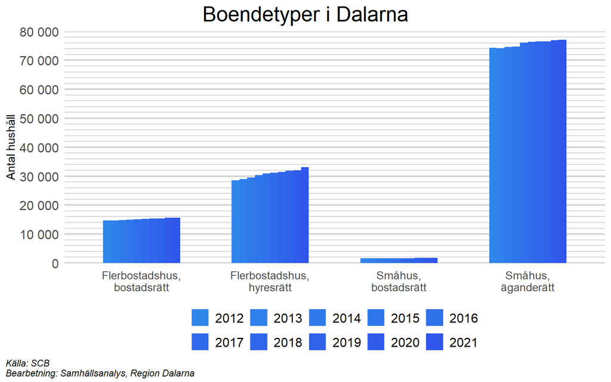

## Tillgång till service och tjänster

Olika platser i Dalarna har olika utmaningar och möjligheter att möta de förändrade behoven, bland annat beroende på om det är platser med växande eller krympande befolkningsunderlag. En princip för genomförandet av Dalastrategin är att allt utvecklingsarbete ska vara platsbaserat med målsättningen att sammanhållningen ska stärkas och olika platsers förutsättningar och resurser ska tas till vara på ett bra sätt. För utvecklingskraft i hela länet är det viktigt att säkra tillgången till service, vård, fritidsaktiviteter och kultur i alla delar av länet. Människor behöver ha en god tillgänglighet till såväl statlig som regional och kommunal service. Tillgången till service påverkar människors levnadsvillkor och är viktig för platsens attraktivitet och för möjligheten att skapa arbetstillfällen på platsen.

Den här indikatorn presenterar två olika mått på tillgång till service; tillgång till grundskola samt tillgång till dagligvarubutik. Tillgång till grundskola har förbättras under perioden från 2010 till 2021. I början på perioden hade drygt 69,5 procent av alla invånare mellan 0-16 år en grundskola inom 2 km från bostaden. 2021 hade motsvarande siffra ökat till 73,7 procent. Samma trend ses inte för tillgång till dagligvarubutiker. Under samma period har andelen med en dagligvarubutik inom 2 km från bostaden minskat från 66,3 procent till 64,7 procent.

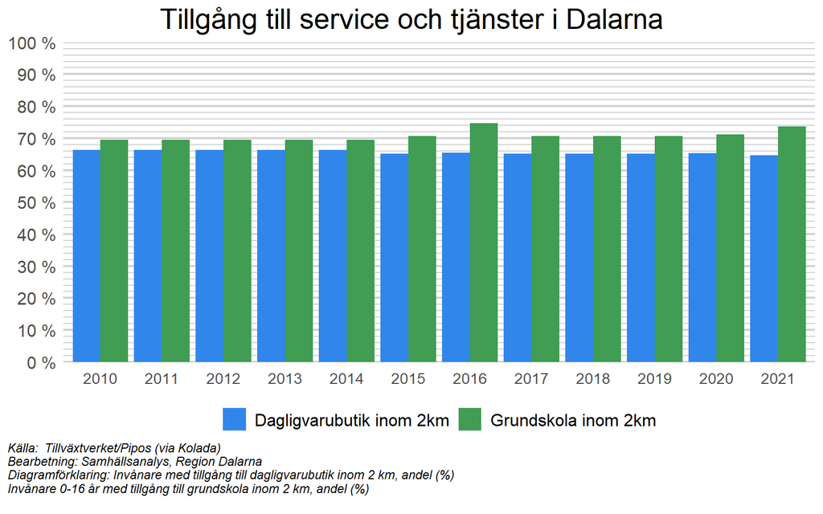

## Deltagande i det civila samhället

Att stärka sammanhållningen och med det den sociala hållbarheten, är viktigt för Dalarnas utveckling. Ett socialt hållbart samhälle tål påfrestningar, är anpassningsbart och resilient. Det är människorna i Dalarna som är regionens främsta resurs – som individer och del av familjer, andra gemenskaper, organisationer och företag. Människors känsla av sammanhang och delaktighet är centrala delar i det vanligtvis benämns socialt kapital.

Denna indikator visar andelen (%) invånare 16-84 år som angett att de deltagit i högst en social aktivitet de senaste 12 månaderna, beräknat genom ett medelvärde över en fyraårsperiod. Med social aktivitet menas en mängd olika former av sätt att interagera med människor som inte tillhör den närmsta familjen. Exempel är studiecirkeldeltagande, besökt scenkonstföreställning, besökt fackligt eller religiöst möte, deltagit på privat fest eller tagit aktiv del av sociala medier. Att under 12 månader inte ha deltagit i mer än en social sammankomst tolkas som att personen har ett lågt socialt deltagande.

Perioden från 2007 till 2022 i Dalarna uppvisar ett antal olika trender och mönster. Från början på perioden fram till 2016 ökade andelen invånare mellan 16-84 år som uppgav att de deltagit i högst en aktivitet totalt sett, ökningen utgörs i praktiken enbart av att en större andel män uppger sig vara mindre socialt aktiva. Under perioden 2015 till 2020 minskar andelen socialt inaktiva män betydligt, från som högst ca 29 procent till som lägst 21 procent, under perioden 2015-2018. Även andelen kvinnor minskar, från som mest ca 24,5 procent till 19 procent under perioden 2015-2018. I samband med, och efter, pandemin verkar dock invånarna ha blivit allt mer isolerade. Det är en markant ökning upp till ca 33 procent när åren 2021 och 2022 läggs till intervallen. Från att ungefär var femte invånare i Dalarna angett att de deltagit i max en aktivitet de senaste 12 månaderna till att var tredje invånare i Dalarna anger detsamma.

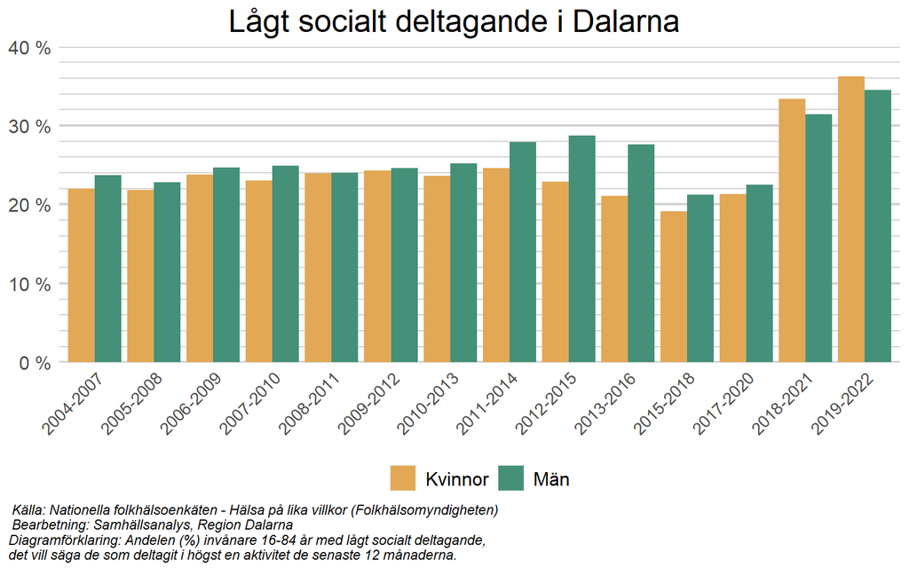

## Andel av hushåll som har tillgång till bredband

Tillgång till en snabb och robust digital infrastruktur är en grundförutsättning för att bo och verka i hela Dalarna. Fysiska och digitala mötesplatser gör att vi når både varandra och omvärlden. En av utmaningarna för Dalarna är en ojämnt fördelad digital infrastruktur. Att stärka och tillgängliggöra den digitala infrastrukturen för hela Dalarnas befolkning, oavsett plats, är avgörande för en lyckad digitalisering av samhället.

I Dalarna har andelen av befolkningen med tillgång, eller möjlighet att ansluta, till bredband om minst 1 Gbit/s ökat från ca 75 procent 2017 till ca 94 procent 2021. Det kan jämföras med riksgenomsnittet som år 2021 var 96,5 procent.

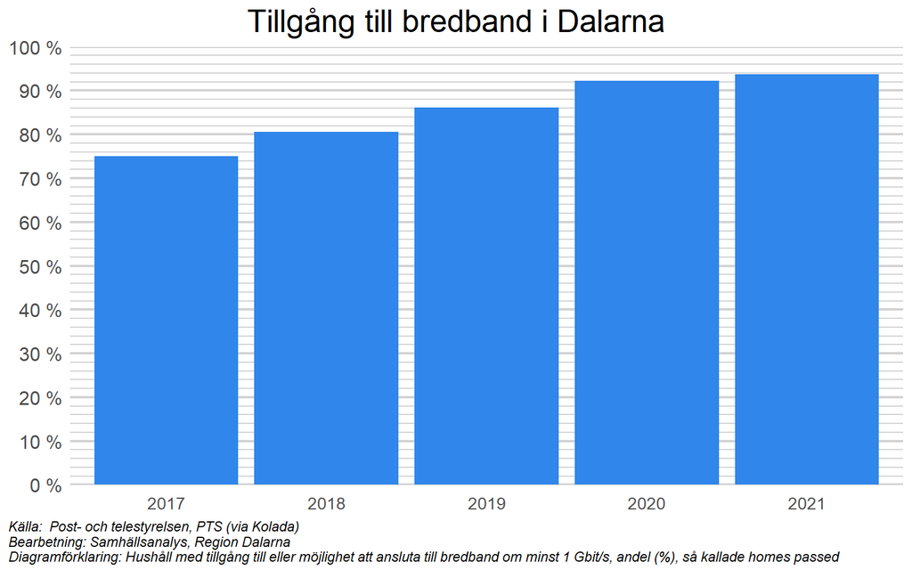

## Valdeltagande

I Dalastrategin belyses att en levande demokrati grundar sig i människors tillit till att de demokratiskt valda representativa institutionerna fungerar, såsom kommuner, region och myndigheter. Valdeltagande är därmed en viktig indikator på invånarnas vilja och tro på de demokratiska institutionerna i länet.

I Dalarna har valdeltagandet i samtliga val ökat mellan valen 1998 och 2018. Exempelvis i kommunvalet valde år 1998 drygt 78,4 procent av invånarna i Dalarna att lägga en röst, medan andelen som röstade år 2018 ökat till drygt 85,4 procent, en ökning med 7 procentenheter.

För 2022 finns siffror för valdeltagandet i region- och riksdagsval men ännu inte för kommunvalet. Resultatet visar på en minskning i valdeltagandet i Dalarna, på båda nivåerna i det senaste valet år 2022.

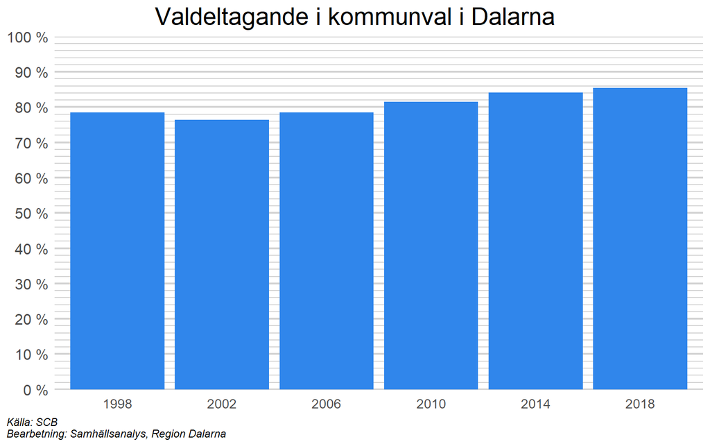

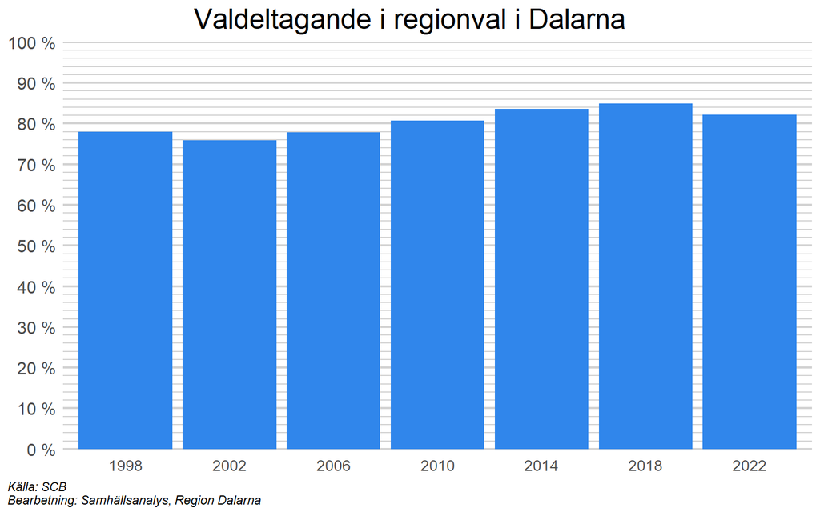

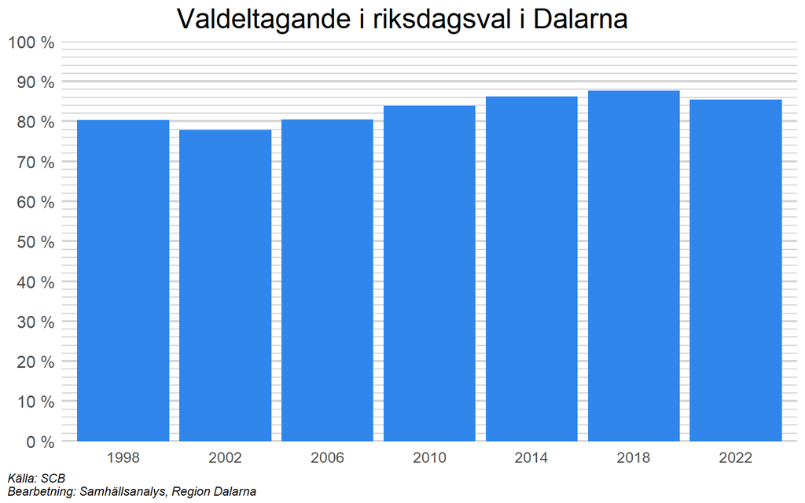

## Tillit till andra människor

Det är människorna i Dalarna som skapar regionen – alla enskilda individer boende i länet, som också är del av familjer och av andra gemenskaper, organisationer och företag. Människors känsla av sammanhang och delaktighet är centralt för att skapa ett väl fungerande samhälle. För att skapa sammanhang och delaktighet behövs tillit mellan dem som ingår i gemenskapen, och det behövs sätt att hantera osäkerhet som kan uppstå när nya medlemmar inkluderas i en gemenskap. Socialt kapital beskriver det kitt som uppstår när en grupp människor enas kring gemensamma värden, normer och värderingar, det får människor att ha tillit till sina medmänniskor och till det gemensamma. Att den representativa demokratins institutioner, såsom kommuner, region och myndigheter, är väl fungerande och att invånarna har förtroende för dem är centralt för en levande demokrati. En stark tillit till andra underlättar samarbetet mellan människor och viljan och förmågan att bidra till samhällsutvecklingen med nya idéer. Ett samhälle med ett starkt socialt kapital är bättre rustat för att möta förändringar och eventuella kriser.

Indikatorn för tillit mäter andel (%) invånare 16-84 år som har uppgett att de anser sig sakna tillit till andra. Värdet är beräknat som medelvärdet över en fyraårsperiod. Mellan tidsperioden 2004-2007 och 2019-2022 visar det sig att andelen som anser sig sakna tillit är ungefär densamma, ca 28 procent. Under intervallet har däremot andelen under perioden 2007 till 2015 varit lägre mellan 23 och 25 procent. Andelen kvinnor som saknar tillit till andra har varit högre än andelen män som saknar tillit till andra fram till ungefär år 2015. Sedan år 2015 är mönstret inte längre entydigt, och det senaste året 2022 uppgav en större andel män, än kvinnor, att de saknade tillit till andra.

Andelen som säger sig sakna tillit utgör ungefär 25 procent av invånarna, samtidigt som det framkommer i folkhälsoenkäten att ca 20 procent av invånarna aldrig eller väldigt sällan deltog i sociala sammankomster före pandemin, och att andelen har ökat till ca 35 procent av invånarna efter pandemin år 2022. Att delta i olika typer av sociala sammankomster är en byggsten för att skapa sammanhang och i förlängningen tillit.

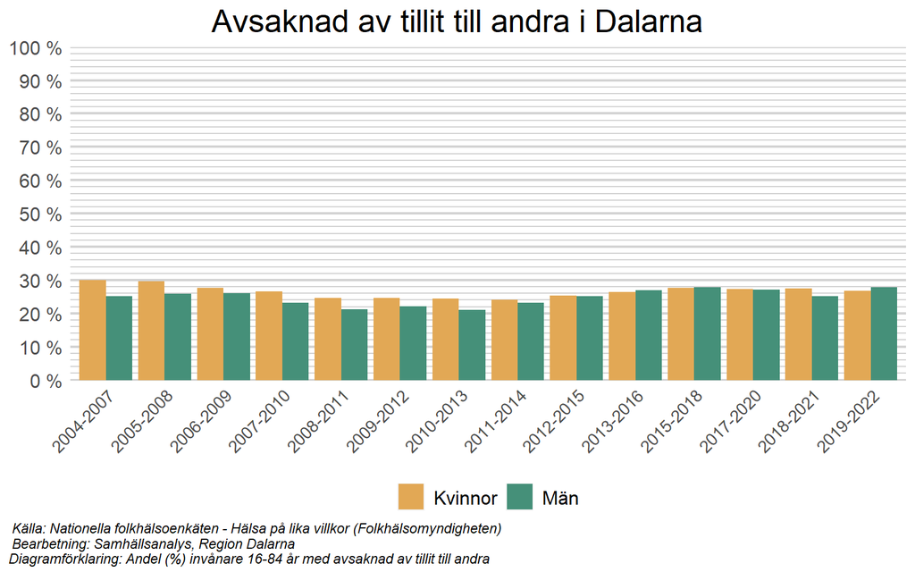

## Andel barn och unga i ekonomiskt utsatta hushåll

Ekonomiska klyftor mellan olika grupper i samhället är en utmaning för både Sverige och Dalarna. Om de socioekonomiska klyftorna blir alltför stora riskerar de att motverka sammanhållning, tillit och trygghet. Det riskerar i sin tur att försvaga demokratin, exempelvis genom systematiska skillnader i valdeltagande, faktiskt eller upplevt inflytande samt delaktighet och engagemang.

Andel barn som lever i ekonomiskt utsatta hushåll är ett mått på levnadsstandard som speglar möjligheterna för en av de mest utsatta grupperna i samhället. Med ekonomiskt utsatta avses hushåll med låg inkomst eller ekonomiskt bistånd (tidigare kallat socialbidrag). Med låg inkomst avses lägsta utgiftsnivå baserad på den socialbidragsnorm, som fastställdes på 1980-talet (med inflationsuppräkningar) och en norm för boendeutgifter. Om inkomsterna understiger dessa normer definieras detta som låg inkomst.

I diagrammet nedan kan vi notera att andelen unga (0-19 år) i ekonomiskt utsatta hushåll i Dalarnas län minskat något över mätperioden, vilket är positivt, från 12,4 procent år 2010 till drygt 11 procent 2020. Lägsta noteringen i tidsspannet var 2016 på 10,6 procent. I ett nationellt perspektiv ser vi att endast tre andra län har en högre andel ekonomiskt utsatta unga än vad Dalarna har.

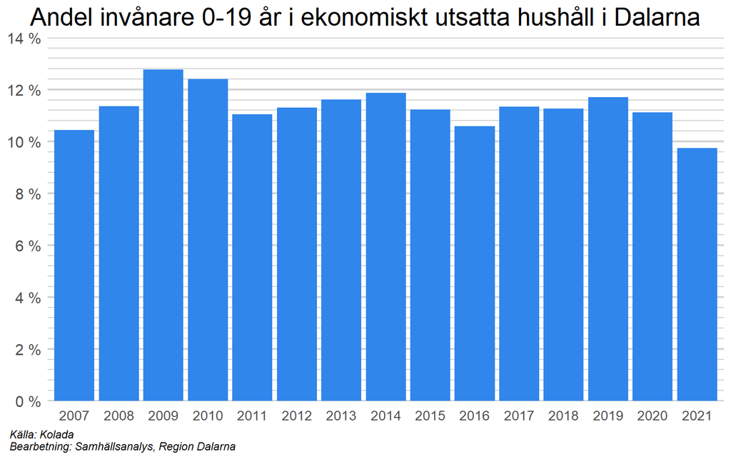

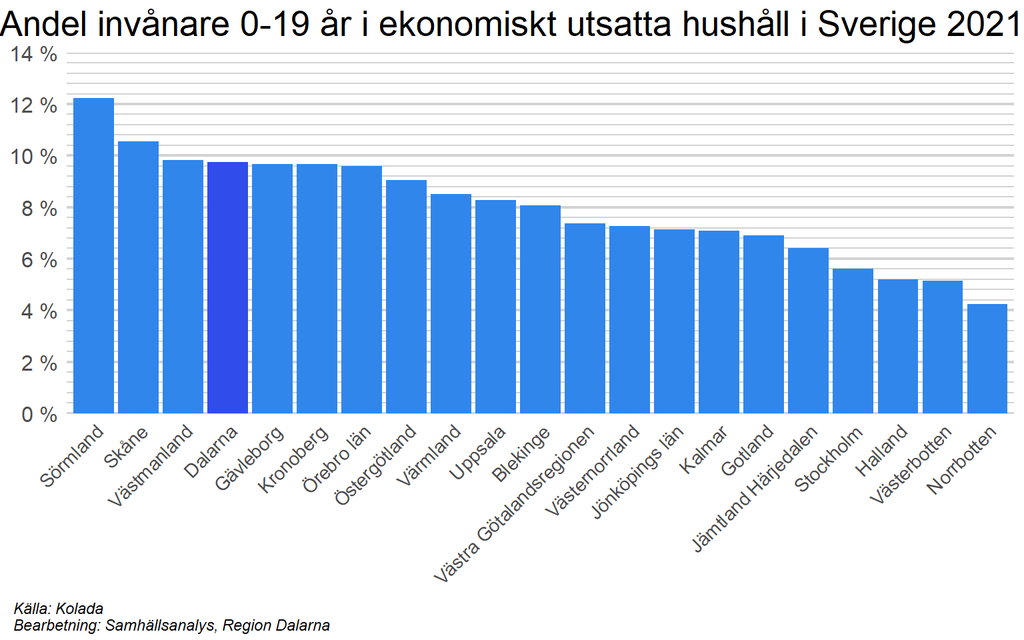

## Andel unga som upplever att de är delaktiga i sin kommun

Att skapa en hållbar utveckling kräver förståelse för och kunskap om framtida generationers utmaningar och behov. FN:s konvention om barns rättigheter, eller barnkonventionen som den ofta kallas, är svensk lag och syftar till att ge barn oavsett bakgrund rätt att behandlas med respekt och att få komma till tals. Barn och unga i Dalarna måste ges möjlighet att ta en aktiv del i samhällsutvecklingen för att målen i Dalastrategin ska kunna uppnås.

För att kunna följa utvecklingen på det här området har en indikator för ungas delaktighet inkluderats i Dalastrategin. Data för indikatorn hämtas från ungdomsenkäten LUPP som genomförs vart tredje år. Här redovisas andelen unga som har angett att de upplever att de har “ganska eller mycket stora möjligheter” att föra fram sina åsikter till dem som bestämmer i kommunen.

Utvecklingen för denna indikator är sammantaget negativ. På gymnasienivå är andelen som har svarat att de anser sig ha möjligheter till delaktighet ungefär lika stor år 2015 som år 2021, 19,8 respektive 19,5 procent. En tydligare negativ trend ses bland högstadieungdomar där andelen som anger att de har möjlighet till delaktighet har sjunkit från 23,4 till 19,0 procent.

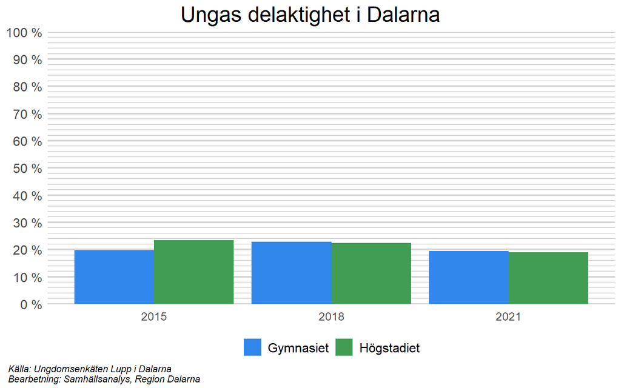

## Självskattad hälsa

En god hälsa är en viktig förutsättning för att utvecklas och vara en aktiv samhällsmedborgare. I Dalastrategin lyfts att jämlika livsvillkor och god hälsa ger alla människor i Dalarna möjlighet att utvecklas.

Folkhälsan mäts genom enkätundersökningar där ett urval av befolkningen (16-84 år) får besvara frågor bland annat om hur de upplever sin hälsostatus. Det är Folkhälsomyndigheten som har i uppdrag att undersöka folkhälsan och dess förutsättningar. Då materialet baseras på enkätsvar ska mindre förändringar och skillnader mellan grupper bedömas med försiktighet.

Av svaren framgår att hälsan varierar både i riket och mellan platser i Dalarnas län. Personer med lägre utbildningsnivå uppger generellt sett en sämre hälsa och sämre förutsättningar för en god hälsa än de med högre utbildningsnivå.

År 2021 var det totalt 69 procent av respondenterna i Dalarnas län som uppgav ett bra eller mycket bra allmänt hälsotillstånd. Under tidsperioden 2014-2021 har det allmänna hälsotillståndet i länet varit stabilt runt 68-69 procent utan några större förändringar. Under samtliga tre uppmätta år har en något större andel av männen svarat att de upplever ett allmänt gott hälsotillstånd i jämförelse med andelen kvinnor, men skillnaden är relativt liten.

I ett nationellt perspektiv ligger alla kommuner i Dalarnas län förutom Älvdalen, under riksgenomsnittet. I 2021 års undersökning uppgav 74 procent av befolkningen i riket att de har ett bra eller mycket bra allmänt hälsotillstånd, samma andel som Älvdalens invånare rapporterade, medan genomsnittet för Dalarnas befolkning var 69 procent, det vill säga 5 procentenheter under riksgenomsnittet. Lägst nivå på andelen med självrapporterad god hälsa finns i Smedjebacken där 66 procent av invånarna ansåg sig ha en allmänt god hälsa. Även på nationell nivå är andelen med god hälsa större bland män än bland kvinnor, och större bland yngre jämfört med äldre.

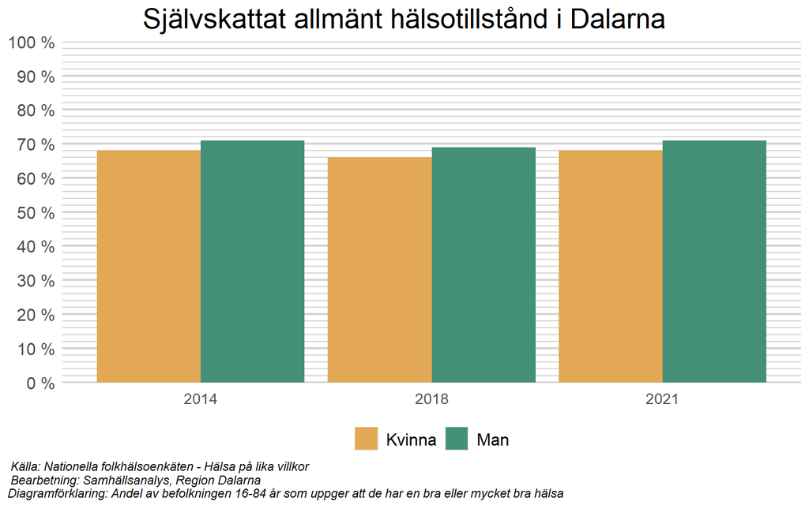

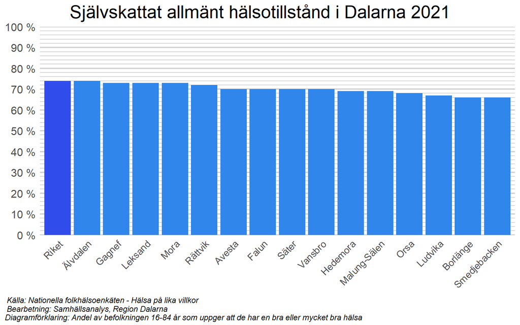